# Purposeful AI Use: Same Principles, Different Design Outcomes

Bodong Chen

cbd@upenn.edu

Penn GSE

# About Me

**Bodong Chen**  
Learning Scientist & Technologist | [Wonder Lab](https://penn-wonderlab.github.io/)  
Penn Graduate School of Education

# Our Challenge

How do we move beyond *banning* or *ignoring* AI to *purposeful engagement*?

**The Reality**

- AI is already in our classrooms
- Students are using it

**The Opportunity**

- Reframe learning objectives
- Model purposeful AI use
- Go beyond “best practices”

## My Pedagogical Groundings

### **Education as Life Itself**

> “Education is not preparation for life; education is life itself.” — John Dewey

### **Authentic Disciplinary Practices**

What do professionals in our disciplines do? How are professional practices evolving?

**The Goal:** Help students become thoughtful, critical users of AI within their disciplines

## My AI Policy

**Responsibility** + **Transparency**

> Generative AI tools can enhance your learning when used thoughtfully… **AI should supplement—not substitute for—your own critical thinking.**

> If you decide to use one of those tools you will not be penalized, instead we would like you to acknowledge when you have used them and where, particularly in your written responses.

# Same Principles, Different Outcomes

## Course 1: Programming Fundamentals

- **Learning Objectives *Changed***
  - **Before AI:** Learn Python syntax and programming concepts
  - **With AI:** Learn to work with **GitHub Copilot** to solve authentic problems
- **Student Experience**
  - AI integrated into learning fundamentals
  - Copilot help explain and generate code
  - Focus shifts to problem-solving and code comprehension

## Course 2: Learning Theories

- **Learning Objectives *Unchanged***
  - Understand foundational learning theories
  - Apply theories to authentic educational problems
- **Student Experience**
  - Students use **ChatLab** (custom tool)
  - Explore connections between personal interests and theories
  - Deeper engagement with complex theoretical concepts

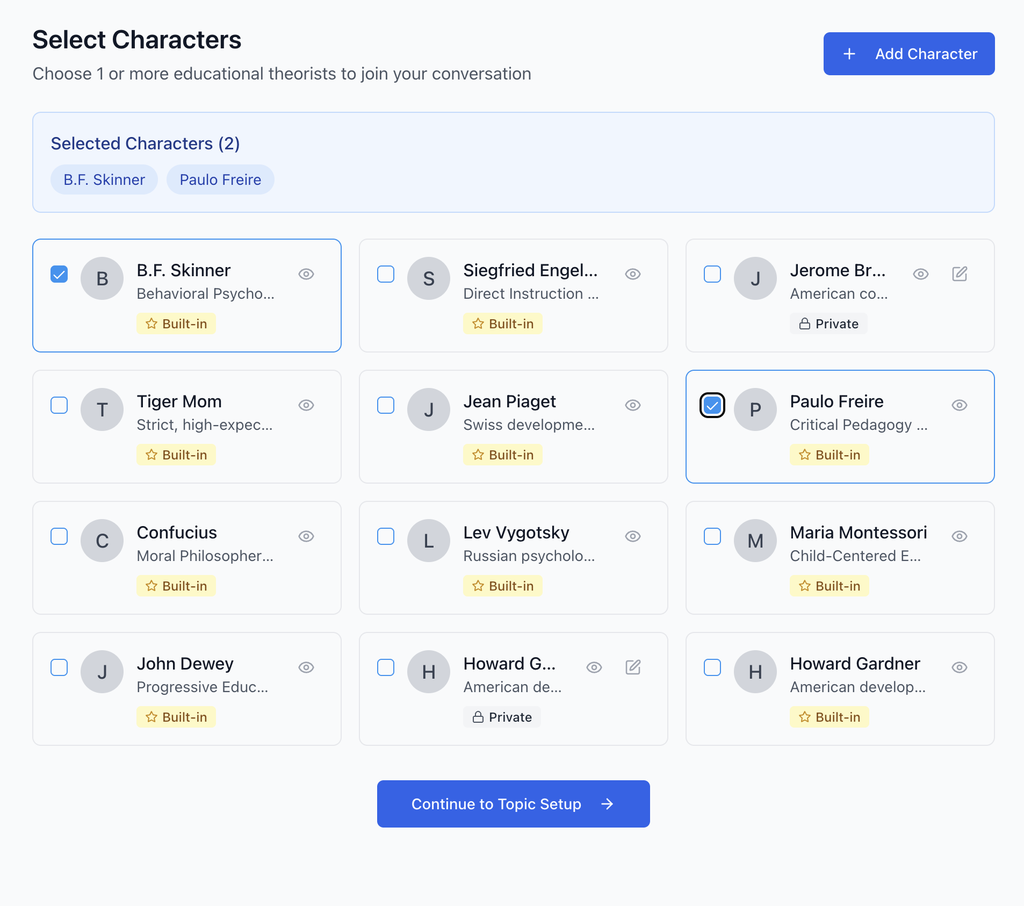

## Augment My Teaching Practice with AI

Generating Reading Scaffolds with **InkSpire** (custom tool)

- Provide scaffolds anchored in disciplinary practices and teaching strategies
- Align with specific learning goals

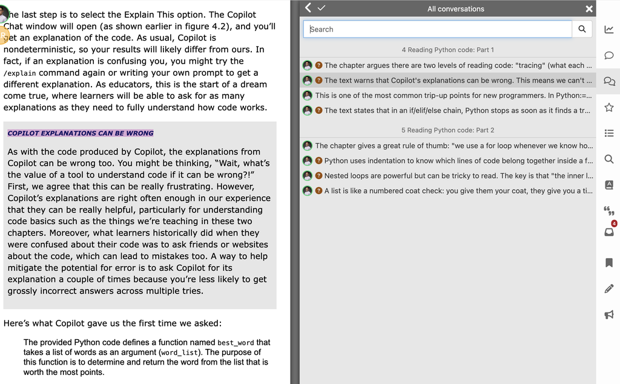

# Key Takeaways

1. **Start with pedagogy**, not technology
2. **Align AI use** with disciplinary practices
3. **Transparency and accountability** builds trust and confidence
4. **Different contexts** require different approaches
5. **Model the behaviors** you want to see

# Happy to Connect

- Share experiences and challenges
- Co-design pedagogical approaches
- Build disciplinary-specific tools

**Email:** cbd@upenn.edu